# Scraping Yahoo Finance IPO Data

Matthew Smith

19/9/2019

I wrote a script a while back when I was working on a project which required the analysis of IPO data, of course I used the IPO data from the bloomberg terminal but I wanted a free source also. Yahoo Finance collects IPO data for a number of worldwide markets, its not clean data but it goes as far back as the year 2000.

I wanted to follow on from some research by J.R.Ritter [here](https://site.warrington.ufl.edu/ritter/files/2019/08/Monnew.pdf). The goal is to try and compute the *money left on the table* from IPO’s and extend the research up until 2018.

**Quote:** *In the 1980s, the average first-day return on initial public offerings (IPOs) was 7%. The average first-day return doubled to almost 15% during 1990-1998, before jumping to 65% during the internet bubble years of 1999-2000 and then reverting to 12% during 2001-2003.*

The code is not clean and if I had to re-write it today I would do so very differently but it works. I just re-download a small sample of the data as it takes some time to process all years but changing `from` to the year 2000 should get you all the data.

```r
library(rvest)
library(naniar)
library(tidyverse)
library(tidyquant)
library(lubridate)
library(knitr)
library(kableExtra)

from = "2019-09-01"
to = "2019-09-19"

s <- seq(as.Date(from), as.Date(to), "days")
url <- "https://finance.yahoo.com/calendar/ipo?from="
links <- gsub(" ", "", paste(url,from,"&to=",to,"&day=",format(s, "%Y-%m-%d")))

store <- NULL
tbl <- NULL

for(i in links){
  store[[i]] = read_html(i)
  tbl[[i]] = html_table(store[[i]])
}


list <- unlist(tbl, recursive = FALSE)
df <- do.call("rbind", list)
df <- df %>%
  replace_with_na_all(condition = ~.x == "-")

data <- df[!is.na(df$Price), ]
```

I get a nice data frame which looks like:

```r
data %>%
  head() %>%
  kable() %>%
  kable_styling(bootstrap_options = c("striped", "hover", "condensed", "responsive"))
```

| Symbol | Company | Exchange | Date | Price Range | Price | Currency | Shares | Actions |
| --- | --- | --- | --- | --- | --- | --- | --- | --- |
| VG8.AX | VGI Partners Asian Invests Ltd | ASX | Aug 04, 2019 | N/A | N/A | AUD | N/A | Amended |
| VG8.AX | VGI Partners Asian Invests Ltd | ASX | Aug 04, 2019 | N/A | N/A | AUD | N/A | Amended |
| VG8.AX | VGI Partners Asian Invests Ltd | ASX | Aug 04, 2019 | N/A | N/A | AUD | N/A | Amended |
|  | China Merchants Coml Reit | HKSE | Sep 02, 2019 | N/A | N/A | USD | N/A | Amended |
|  | Immunotech Biopharm Ltd | HKSE | Sep 02, 2019 | N/A | N/A | USD | N/A | Amended |
|  | Nusantara Almazia PT | Jakarta | Aug 12, 2019 | N/A | N/A | IDR | 461530000 | Amended |

Theres lot of missing IPO price data and many duplicate results since this is just a calendar and thus reports on any news about an IPO.

I next get the stock price information: - which can take some time so I suggest saving the results.

```r
symbols <- df$Symbol
symbols <- symbols[symbols != ""]

stocks <- symbols %>%
  tq_get("stock.prices",
         from = from,
         to = to)

stocks %>%
  head() %>%
  kable() %>%
  kable_styling(bootstrap_options = c("striped", "hover", "condensed", "responsive"))
```

| symbol | date | open | high | low | close | volume | adjusted |
| --- | --- | --- | --- | --- | --- | --- | --- |
| SDC | 2019-09-12 | 20.59 | 21.10 | 16.28 | 16.67 | 55416800 | 16.67 |
| SDC | 2019-09-13 | 16.81 | 18.71 | 16.81 | 18.68 | 19119100 | 18.68 |
| SDC | 2019-09-16 | 18.46 | 19.00 | 17.81 | 18.90 | 5573000 | 18.90 |
| SDC | 2019-09-17 | 19.00 | 19.30 | 18.65 | 19.07 | 4415200 | 19.07 |
| SDC | 2019-09-18 | 19.17 | 19.70 | 18.90 | 19.48 | 10533900 | 19.48 |
| TXG | 2019-09-12 | 54.00 | 58.00 | 51.00 | 52.75 | 7326300 | 52.75 |

Next I join the daily stock price data with the IPO data, clean it up a little and compute the returns. I also split the data into different markets such as NYSE, LSE, Frankfurt etc. and compute the average daily returns. You can find everything along with the [excel](https://github.com/msmith01/IPO_Web_Scraping_Yahoo/blob/master/yahoo_finance_IPOs_2000_2018.csv) file collecting IPOs since 2000 [here](https://github.com/msmith01/IPO_Web_Scraping_Yahoo).

Heres how the final data looks:

```r
read.csv("https://raw.githubusercontent.com/msmith01/IPO_Web_Scraping_Yahoo/master/yahoo_finance_IPOs_2000_2018.csv", nrows = 10) %>%
  kable() %>%
  kable_styling(bootstrap_options = c("striped", "hover", "condensed", "responsive"))
```

| X | symbol | company | exchange | date.x | price | currency | actions | date.y | open | close | adjusted | returns | year |
| --- | --- | --- | --- | --- | --- | --- | --- | --- | --- | --- | --- | --- | --- |
| 1 | EVD.F | CTS Eventim AG | Frankfurt | 2000-01-31 | 21.50 | EUR | Priced | 2000-02-01 | 6.37500 | 6.30000 | 4.990930 | -0.7069767 | 2000 |
| 2 | SLAB | Silicon Laboratories Inc | NasdaqGM | 2000-03-24 | 31.00 | USD | Priced | 2000-03-24 | 63.00000 | 69.37500 | 69.375000 | 1.2379032 | 2000 |
| 3 | 0764.HK | Ocean Shores Group Ltd | HKSE | 2000-02-10 | 1.33 | HKD | Priced | 2005-09-29 | 9984.20996 | 9984.20996 | 9946.558594 | 7505.9247827 | 2000 |
| 4 | MTB.V | Mountain Boy Minerals Ltd | TSXV | 2000-07-12 | 0.35 | CAD | Priced | 2000-07-12 | 0.35000 | 0.35000 | 0.350000 | 0.0000000 | 2000 |
| 5 | IAG.TO | Industrial-Alliance Life | Toronto | 2000-02-10 | 15.75 | CAD | Priced | 2000-02-10 | 8.50000 | 8.70000 | 5.096976 | -0.4476190 | 2000 |
| 6 | 2457.TW | Phihong Enterprises Co Ltd | Taiwan | 2000-02-15 | 111.00 | TWD | Priced | 2000-02-16 | 55.19920 | 55.19920 | 28.781498 | -0.5027099 | 2000 |
| 7 | IFX.F | Infineon Technologies AG | Frankfurt | 2000-03-14 | 35.00 | EUR | Priced | 2000-03-14 | 71.50000 | 79.00000 | 69.923615 | 1.2571429 | 2000 |
| 8 | BRC.V | BRC Development Corp | TSXV | 2000-02-24 | 0.50 | CAD | Priced | 2000-07-20 | 0.35000 | 0.40000 | 0.400000 | -0.2000000 | 2000 |
| 9 | PTR | PetroChina Co Ltd | NYSE | 2000-04-07 | 16.44 | USD | Priced | 2000-04-06 | 16.43750 | 16.43750 | 7.569896 | -0.0001521 | 2000 |
| 10 | 0643.HK | Carry Wealth Holdings Ltd | HKSE | 2000-03-09 | 1.00 | HKD | Priced | 2000-03-14 | 0.78389 | 0.70833 | 0.332258 | -0.2916700 | 2000 |

I try to recreate some of the plots on J.R.Ritters website for each of the countries.

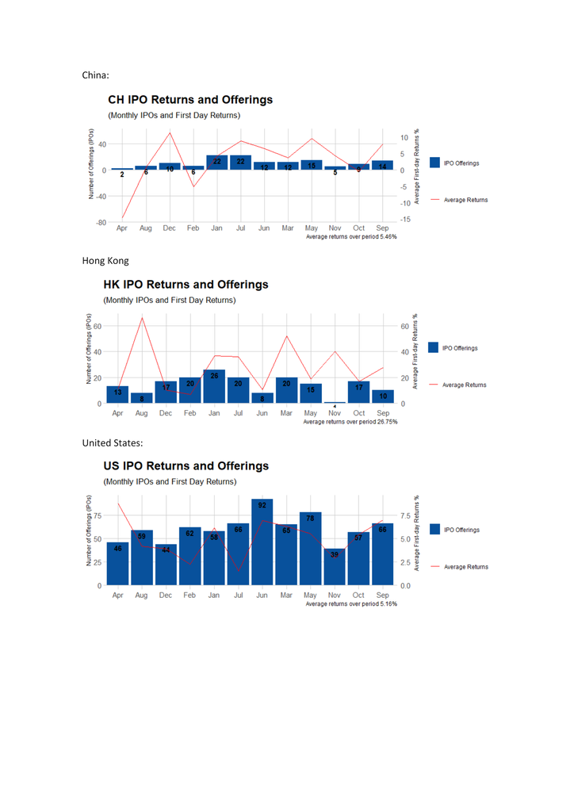

```r
knitr::include_graphics("../_posts/posts_img/Monthly_bloomberg_graphs.png")
```

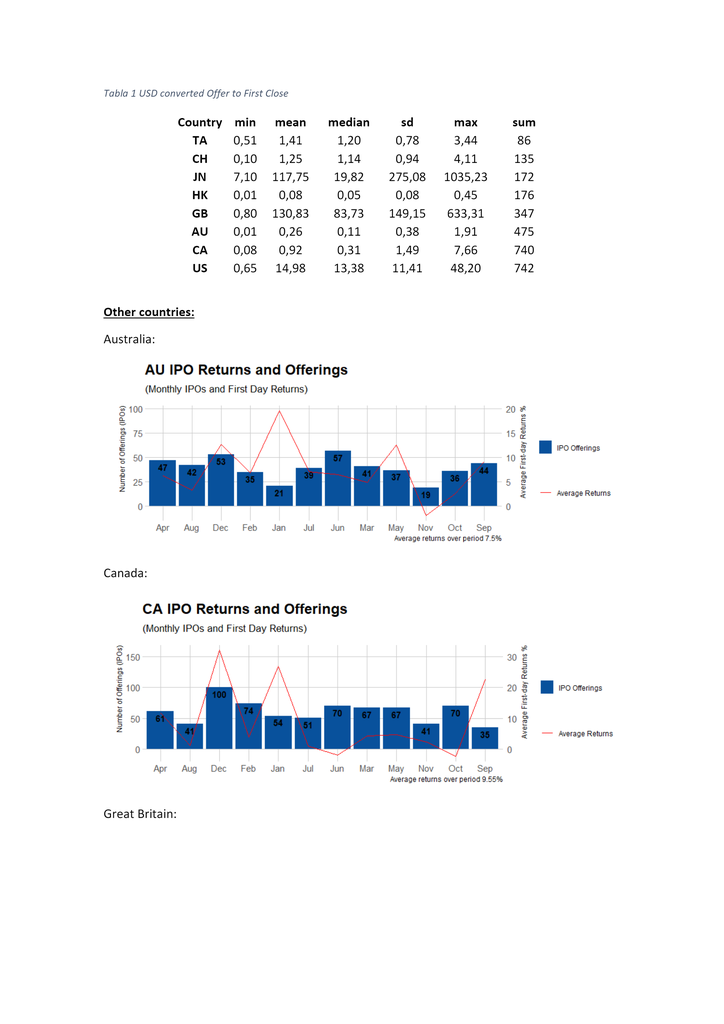

```r
knitr::include_graphics("../_posts/posts_img/Monthly_bloomberg_graphs2.png")
```

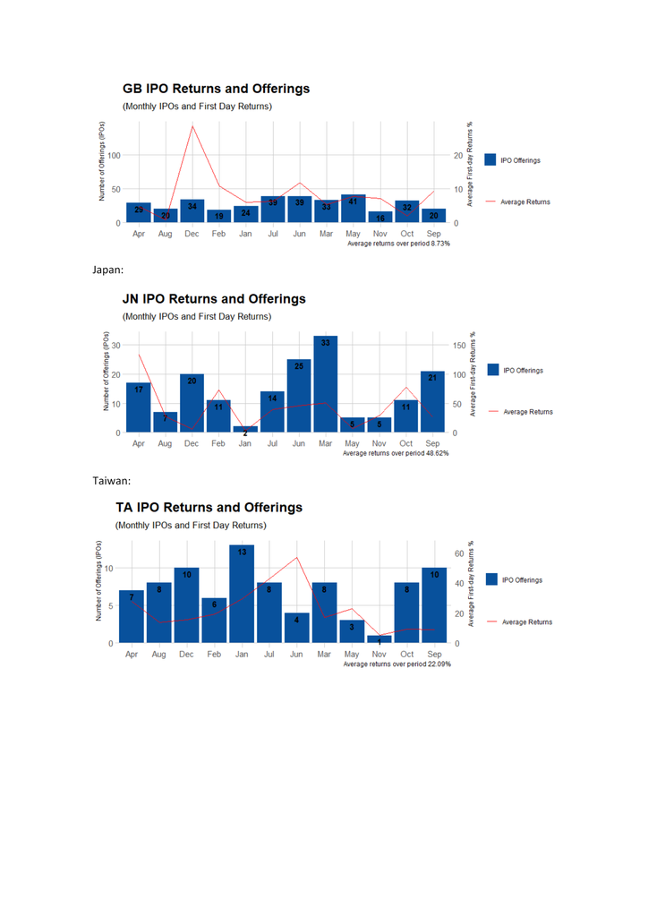

```r
knitr::include_graphics("../_posts/posts_img/Monthly_bloomberg_graphs3.png")
```

See J.R.Ritter for other [IPO data.](https://site.warrington.ufl.edu/ritter/ipo-data/) See Tim Loughran and Jay Ritter [IPO returns:](https://site.warrington.ufl.edu/ritter/files/2016/06/why-has-IPO-Underpricing-Increased-Over-Time.pdf)